# Practica 3 | Diplomado en ciencia de datos

# Luis Manuel Álamo Díaz

```python
import pandas as pd
import numpy as np
from sklearn.impute import KNNImputer
import seaborn as sns
import matplotlib.pyplot as plt
```

```python
#df = pd.read_csv(r'E:\Users\1070911\Luis DCD\CTG.csv')
df = pd.read_csv('CTG.csv')
#df.head()
df.info()
df.describe()
```

```
<class 'pandas.core.frame.DataFrame'>
RangeIndex: 2129 entries, 0 to 2128
Data columns (total 40 columns):
 #   Column    Non-Null Count  Dtype
---  ------    --------------  -----
 0   FileName  2126 non-null   object
 1   Date      2126 non-null   object
 2   SegFile   2126 non-null   object
 3   b         2126 non-null   float64
 4   e         2126 non-null   float64
 5   LBE       2126 non-null   float64
 6   LB        2126 non-null   float64
 7   AC        2126 non-null   float64
 8   FM        2127 non-null   float64
 9   UC        2127 non-null   float64
```

[output cut: 32 more lines]

|  | b | e | LBE | LB | AC | FM | UC | ASTV | MSTV | ALTV | ... | C | D | E | AD | DE | LD | FS | SUSP | CLASS | NSP |
| --- | --- | --- | --- | --- | --- | --- | --- | --- | --- | --- | --- | --- | --- | --- | --- | --- | --- | --- | --- | --- | --- |
| count | 2126.000000 | 2126.000000 | 2126.000000 | 2126.000000 | 2126.000000 | 2127.000000 | 2127.000000 | 2127.000000 | 2127.000000 | 2127.000000 | ... | 2126.000000 | 2126.000000 | 2126.000000 | 2126.000000 | 2126.000000 | 2126.000000 | 2126.000000 | 2126.000000 | 2126.000000 | 2126.000000 |
| mean | 878.439793 | 1702.877234 | 133.303857 | 133.303857 | 2.722484 | 7.503056 | 3.669017 | 47.008933 | 1.335449 | 9.884814 | ... | 0.024929 | 0.038100 | 0.033866 | 0.156162 | 0.118532 | 0.050329 | 0.032455 | 0.092662 | 4.509878 | 1.304327 |
| std | 894.084748 | 930.919143 | 9.840844 | 9.840844 | 3.560850 | 39.030452 | 2.877148 | 17.210648 | 0.891543 | 18.476534 | ... | 0.155947 | 0.191482 | 0.180928 | 0.363094 | 0.323314 | 0.218675 | 0.177248 | 0.290027 | 3.026883 | 0.614377 |
| min | 0.000000 | 287.000000 | 106.000000 | 106.000000 | 0.000000 | 0.000000 | 0.000000 | 12.000000 | 0.200000 | 0.000000 | ... | 0.000000 | 0.000000 | 0.000000 | 0.000000 | 0.000000 | 0.000000 | 0.000000 | 0.000000 | 1.000000 | 1.000000 |
| 25% | 55.000000 | 1009.000000 | 126.000000 | 126.000000 | 0.000000 | 0.000000 | 1.000000 | 32.000000 | 0.700000 | 0.000000 | ... | 0.000000 | 0.000000 | 0.000000 | 0.000000 | 0.000000 | 0.000000 | 0.000000 | 0.000000 | 2.000000 | 1.000000 |
| 50% | 538.000000 | 1241.000000 | 133.000000 | 133.000000 | 1.000000 | 0.000000 | 3.000000 | 49.000000 | 1.200000 | 0.000000 | ... | 0.000000 | 0.000000 | 0.000000 | 0.000000 | 0.000000 | 0.000000 | 0.000000 | 0.000000 | 4.000000 | 1.000000 |
| 75% | 1521.000000 | 2434.750000 | 140.000000 | 140.000000 | 4.000000 | 2.000000 | 5.000000 | 61.000000 | 1.700000 | 11.000000 | ... | 0.000000 | 0.000000 | 0.000000 | 0.000000 | 0.000000 | 0.000000 | 0.000000 | 0.000000 | 7.000000 | 1.000000 |
| max | 3296.000000 | 3599.000000 | 160.000000 | 160.000000 | 26.000000 | 564.000000 | 23.000000 | 87.000000 | 7.000000 | 91.000000 | ... | 1.000000 | 1.000000 | 1.000000 | 1.000000 | 1.000000 | 1.000000 | 1.000000 | 1.000000 | 10.000000 | 3.000000 |

8 rows × 37 columns

### 1. Preprocesamiento

#### Eliminar columnas con más del 20% de valores nulos

```python
#conteo de valores nulos

df.isna().mean()*100 #porcentaje
#df.isna().sum()#conteo de valores nulos
```

```
FileName    0.140911
Date        0.140911
SegFile     0.140911
b           0.140911
e           0.140911
LBE         0.140911
LB          0.140911
AC          0.140911
FM          0.093941
UC          0.093941
ASTV        0.093941
MSTV        0.093941
ALTV        0.093941
MLTV        0.093941
DL          0.046970
DS          0.046970
DP          0.046970
DR          0.046970
Width       0.140911
Min         0.140911
Max         0.140911
Nmax        0.140911
Nzeros      0.140911
Mode        0.140911
Mean        0.140911
Median      0.140911
Variance    0.140911
Tendency    0.140911
A           0.140911
B           0.140911
C           0.140911
D           0.140911
E           0.140911
AD          0.140911
DE          0.140911
LD          0.140911
FS          0.140911
SUSP        0.140911
CLASS       0.140911
NSP         0.140911
dtype: float64
```

Ninguna columan supera el 1% de valores nulos, por lo que conservamos todas las columnas.

#### Imputar valores faltantes restantes con métodos adecuados:

```python
#imputación de valores

unique_counts = df.nunique()

df_imp = df.copy()

# Clasificamos (columanas numericas con 10 o. más valores unicos son numericas)
discretas = [col for col in df_imp.columns if unique_counts[col] < 10]
continuas = [col for col in df_imp.columns if unique_counts[col] >= 10]

cols_num = df_imp.select_dtypes(include=["number"]).columns
#cols_cat = df_imp.select_dtypes(exclude=["number"]).columns

#discretas = [col for col in discretas if col in cols_cat]
continuas = [col for col in continuas if col in cols_num]

for col in continuas:
    valor = df_imp[col].mean()
    df_imp[col] = df_imp[col].fillna(valor)

print(df_imp.isna().mean()*100)
print('Se imputaron todas las columnas continuas')
```

```
FileName    0.140911
Date        0.140911
SegFile     0.140911
b           0.000000
e           0.000000
LBE         0.000000
LB          0.000000
AC          0.000000
FM          0.000000
UC          0.000000
ASTV        0.000000
MSTV        0.000000
ALTV        0.000000
MLTV        0.000000
DL          0.000000
DS          0.046970
DP          0.046970
DR          0.046970
Width       0.000000
Min         0.000000
Max         0.000000
Nmax        0.000000
Nzeros      0.140911
Mode        0.000000
Mean        0.000000
Median      0.000000
Variance    0.000000
Tendency    0.140911
A           0.140911
B           0.140911
C           0.140911
D           0.140911
E           0.140911
AD          0.140911
DE          0.140911
LD          0.140911
FS          0.140911
SUSP        0.140911
CLASS       0.000000
NSP         0.140911
dtype: float64
Se imputaron todas las columnas continuas
```

```python
# Categóricos
for col in discretas:
    if df_imp[col].isna().all():
        continue
    moda = df_imp[col].mode(dropna=True)
    if len(moda) > 0:
        valor = moda.iloc[0]
        df_imp[col] = df_imp[col].fillna(valor)

print(df_imp.isna().mean()*100)
print('\n Se imputaron todas las columnas discretas')
```

```
FileName    0.140911
Date        0.140911
SegFile     0.140911
b           0.000000
e           0.000000
LBE         0.000000
LB          0.000000
AC          0.000000
FM          0.000000
UC          0.000000
ASTV        0.000000
MSTV        0.000000
ALTV        0.000000
MLTV        0.000000
DL          0.000000
DS          0.000000
DP          0.000000
DR          0.000000
Width       0.000000
Min         0.000000
Max         0.000000
Nmax        0.000000
Nzeros      0.000000
Mode        0.000000
Mean        0.000000
Median      0.000000
Variance    0.000000
Tendency    0.000000
A           0.000000
B           0.000000
C           0.000000
D           0.000000
E           0.000000
AD          0.000000
DE          0.000000
LD          0.000000
FS          0.000000
SUSP        0.000000
CLASS       0.000000
NSP         0.000000
dtype: float64

 Se imputaron todas las columnas discretas
```

KNN Imputer (reto adicional) 5% adicional

```python
df_imp_knn = df.copy()
df_imp_knn.isna().mean()
```

```
FileName    0.001409
Date        0.001409
SegFile     0.001409
b           0.001409
e           0.001409
LBE         0.001409
LB          0.001409
AC          0.001409
FM          0.000939
UC          0.000939
ASTV        0.000939
MSTV        0.000939
ALTV        0.000939
MLTV        0.000939
DL          0.000470
DS          0.000470
DP          0.000470
DR          0.000470
Width       0.001409
Min         0.001409
Max         0.001409
Nmax        0.001409
Nzeros      0.001409
Mode        0.001409
Mean        0.001409
Median      0.001409
Variance    0.001409
Tendency    0.001409
A           0.001409
B           0.001409
C           0.001409
D           0.001409
E           0.001409
AD          0.001409
DE          0.001409
LD          0.001409
FS          0.001409
SUSP        0.001409
CLASS       0.001409
NSP         0.001409
dtype: float64
```

```python
cols_numericas = None
if cols_numericas is None:
    cols_numericas = df_imp_knn.select_dtypes(include=["number"]).columns.tolist()

imputer = KNNImputer(n_neighbors=5)
datos_num = df_imp_knn[cols_numericas]
datos_imputados = imputer.fit_transform(datos_num)
df_imp_knn[cols_numericas] = datos_imputados
print('Se imputo usando el metodo KNN')
```

```
Se imputo usando el metodo KNN
```

```python
df_imp_knn.isna().sum()
```

```
FileName    3
Date        3
SegFile     3
b           0
e           0
LBE         0
LB          0
AC          0
FM          0
UC          0
ASTV        0
MSTV        0
ALTV        0
MLTV        0
DL          0
DS          0
DP          0
DR          0
Width       0
Min         0
Max         0
Nmax        0
Nzeros      0
Mode        0
Mean        0
Median      0
Variance    0
Tendency    0
A           0
B           0
C           0
D           0
E           0
AD          0
DE          0
LD          0
FS          0
SUSP        0
CLASS       0
NSP         0
dtype: int64
```

#### Detectar y tratar valores atípicos (outliers) con IQR o z-score

```python
#OUTLIERS

df_proc = df_imp.copy()
columnas = None
factor = 1.5

print(f"Tamaño original: {len(df_proc)}")

if columnas is None:
    columnas = df_proc.select_dtypes(include=["number"]).columns.tolist()

filas_a_eliminar = np.zeros(len(df_proc), dtype=bool)

for col in columnas:
    serie = df_proc[col].dropna()
    q1 = serie.quantile(0.25)
    q3 = serie.quantile(0.75)
    iqr = q3 - q1
    lim_inf = q1 - factor * iqr
    lim_sup = q3 + factor * iqr

    mask_out = (df_proc[col] < lim_inf) | (df_proc[col] > lim_sup)
    filas_a_eliminar = filas_a_eliminar | mask_out
df_proc_iqr = df_proc.loc[~filas_a_eliminar].reset_index(drop=True)
print(f"Outliers eliminados: {len(df_proc) - len(df_proc_iqr)}")

print(f"Tamaño del df despues de sacar outliers: {len(df_proc_iqr)}")
```

[output not shown]

```python
#Z-score
umbral = 3
# Seleccionamos solo columnas numéricas
cols_num = df_proc.select_dtypes(include=["number"])

# Calculamos Z-score
z_scores = (cols_num - cols_num.mean()) / cols_num.std()

# Creamos máscara de outliers (True = outlier)
mask_outliers = np.abs(z_scores) > umbral

# Filtramos filas que contengan algún outlier
outliers_df = df_proc[mask_outliers.any(axis=1)]
df_sin_outliers = df_proc[~mask_outliers.any(axis=1)].reset_index(drop=True)

print(f"Outliers eliminados: {len(df_imp) - len(df_sin_outliers)}")
len(df_sin_outliers)
```

```
Outliers eliminados: 743
```

```
1386
```

### 2. Análisis de Datos

#### Crear una función general check_data_completeness_nomnbrecompleto(df) que retorne:

Conteo de nulos

Porcentaje de completitud

Tipo de dato

Estadísticos de dispersión

Clasificar automáticamente columnas en:

Continuas (más de 10 valores únicos y tipo numérico)

Discretas (menos de 10 valores únicos)

```python
#creación de funcion
def check_data_completeness_luis_manuel_alamo_diaz(df: pd.DataFrame) -> pd.DataFrame:

    filas_resumen = []

    unique_counts = df.nunique(dropna=True)
    cols_num = df.select_dtypes(include=["number"]).columns

    for col in df.columns:
        serie = df[col]
        n_nulos = serie.isna().sum()
        prop_nulos = n_nulos / len(serie)
        porcentaje_completitud = (1 - prop_nulos) * 100
        tipo_dato = serie.dtype
        n_unicos = unique_counts[col]


        if col in cols_num:
            if n_unicos < 10:
                tipo_variable = "discreta"
            else:
                tipo_variable = "continua"
        else:
            tipo_variable = "no_numerica"# No numéricas (texto,fechas, etc.)


        fila = {
            "columna": col,
            "n_nulos": n_nulos,
            "porcentaje_completitud": porcentaje_completitud,
            "tipo_dato": str(tipo_dato),
            "n_unicos": n_unicos,
            "tipo_variable": tipo_variable,
        }


        if pd.api.types.is_numeric_dtype(serie):
            fila.update(
                {
                    "min": serie.min(),
                    "max": serie.max(),
                    "media": serie.mean(),
                    "std": serie.std(),
                    "var": serie.var(),
                }
            )
        else:
            fila.update(
                {
                    "min": None,
                    "max": None,
                    "media": None,
                    "std": None,
                    "var": None,
                }
            )
        filas_resumen.append(fila)

    resumen = pd.DataFrame(filas_resumen)
    return resumen.set_index("columna")

check_data_completeness_luis_manuel_alamo_diaz(df)
```

| columna | n_nulos | porcentaje_completitud | tipo_dato | n_unicos | tipo_variable | min | max | media | std | var |
| --- | --- | --- | --- | --- | --- | --- | --- | --- | --- | --- |
| FileName | 3 | 99.859089 | object | 352 | no_numerica | NaN | NaN | NaN | NaN | NaN |
| Date | 3 | 99.859089 | object | 48 | no_numerica | NaN | NaN | NaN | NaN | NaN |
| SegFile | 3 | 99.859089 | object | 2126 | no_numerica | NaN | NaN | NaN | NaN | NaN |
| b | 3 | 99.859089 | float64 | 979 | continua | 0.0 | 3296.0 | 878.439793 | 894.084748 | 799387.535903 |
| e | 3 | 99.859089 | float64 | 1064 | continua | 287.0 | 3599.0 | 1702.877234 | 930.919143 | 866610.450333 |
| LBE | 3 | 99.859089 | float64 | 48 | continua | 106.0 | 160.0 | 133.303857 | 9.840844 | 96.842216 |
| LB | 3 | 99.859089 | float64 | 48 | continua | 106.0 | 160.0 | 133.303857 | 9.840844 | 96.842216 |
| AC | 3 | 99.859089 | float64 | 22 | continua | 0.0 | 26.0 | 2.722484 | 3.560850 | 12.679654 |
| FM | 2 | 99.906059 | float64 | 96 | continua | 0.0 | 564.0 | 7.503056 | 39.030452 | 1523.376167 |
| UC | 2 | 99.906059 | float64 | 19 | continua | 0.0 | 23.0 | 3.669017 | 2.877148 | 8.277981 |
| ASTV | 2 | 99.906059 | float64 | 75 | continua | 12.0 | 87.0 | 47.008933 | 17.210648 | 296.206411 |
| MSTV | 2 | 99.906059 | float64 | 57 | continua | 0.2 | 7.0 | 1.335449 | 0.891543 | 0.794848 |
| ALTV | 2 | 99.906059 | float64 | 87 | continua | 0.0 | 91.0 | 9.884814 | 18.476534 | 341.382305 |
| MLTV | 2 | 99.906059 | float64 | 249 | continua | 0.0 | 50.7 | 8.207616 | 5.701926 | 32.511955 |
| DL | 1 | 99.953030 | float64 | 15 | continua | 0.0 | 16.0 | 1.576128 | 2.517794 | 6.339289 |
| DS | 1 | 99.953030 | float64 | 2 | discreta | 0.0 | 1.0 | 0.003759 | 0.061213 | 0.003747 |
| DP | 1 | 99.953030 | float64 | 5 | discreta | 0.0 | 4.0 | 0.127820 | 0.471687 | 0.222489 |
| DR | 1 | 99.953030 | float64 | 1 | discreta | 0.0 | 0.0 | 0.000000 | 0.000000 | 0.000000 |
| Width | 3 | 99.859089 | float64 | 154 | continua | 3.0 | 180.0 | 70.445908 | 38.955693 | 1517.546014 |
| Min | 3 | 99.859089 | float64 | 109 | continua | 50.0 | 159.0 | 93.579492 | 29.560212 | 873.806149 |
| Max | 3 | 99.859089 | float64 | 86 | continua | 122.0 | 238.0 | 164.025400 | 17.944183 | 321.993707 |
| Nmax | 3 | 99.859089 | float64 | 18 | continua | 0.0 | 18.0 | 4.068203 | 2.949386 | 8.698876 |
| Nzeros | 3 | 99.859089 | float64 | 9 | discreta | 0.0 | 10.0 | 0.323612 | 0.706059 | 0.498520 |
| Mode | 3 | 99.859089 | float64 | 88 | continua | 60.0 | 187.0 | 137.452023 | 16.381289 | 268.346638 |
| Mean | 3 | 99.859089 | float64 | 103 | continua | 73.0 | 182.0 | 134.610536 | 15.593596 | 243.160247 |
| Median | 3 | 99.859089 | float64 | 95 | continua | 77.0 | 186.0 | 138.090310 | 14.466589 | 209.282193 |
| Variance | 3 | 99.859089 | float64 | 133 | continua | 0.0 | 269.0 | 18.808090 | 28.977636 | 839.703389 |
| Tendency | 3 | 99.859089 | float64 | 3 | discreta | -1.0 | 1.0 | 0.320320 | 0.610829 | 0.373112 |
| A | 3 | 99.859089 | float64 | 2 | discreta | 0.0 | 1.0 | 0.180621 | 0.384794 | 0.148067 |
| B | 3 | 99.859089 | float64 | 2 | discreta | 0.0 | 1.0 | 0.272342 | 0.445270 | 0.198265 |
| C | 3 | 99.859089 | float64 | 2 | discreta | 0.0 | 1.0 | 0.024929 | 0.155947 | 0.024319 |
| D | 3 | 99.859089 | float64 | 2 | discreta | 0.0 | 1.0 | 0.038100 | 0.191482 | 0.036665 |
| E | 3 | 99.859089 | float64 | 2 | discreta | 0.0 | 1.0 | 0.033866 | 0.180928 | 0.032735 |
| AD | 3 | 99.859089 | float64 | 2 | discreta | 0.0 | 1.0 | 0.156162 | 0.363094 | 0.131837 |
| DE | 3 | 99.859089 | float64 | 2 | discreta | 0.0 | 1.0 | 0.118532 | 0.323314 | 0.104532 |
| LD | 3 | 99.859089 | float64 | 2 | discreta | 0.0 | 1.0 | 0.050329 | 0.218675 | 0.047819 |
| FS | 3 | 99.859089 | float64 | 2 | discreta | 0.0 | 1.0 | 0.032455 | 0.177248 | 0.031417 |
| SUSP | 3 | 99.859089 | float64 | 2 | discreta | 0.0 | 1.0 | 0.092662 | 0.290027 | 0.084116 |
| CLASS | 3 | 99.859089 | float64 | 10 | continua | 1.0 | 10.0 | 4.509878 | 3.026883 | 9.162020 |
| NSP | 3 | 99.859089 | float64 | 3 | discreta | 1.0 | 3.0 | 1.304327 | 0.614377 | 0.377459 |

```python
columnas_numericas = df.select_dtypes(include="number").columns
```

### 3. Visualizaciones (eleva dificultad agregando interactividad, estadísticas o múltiples variables)

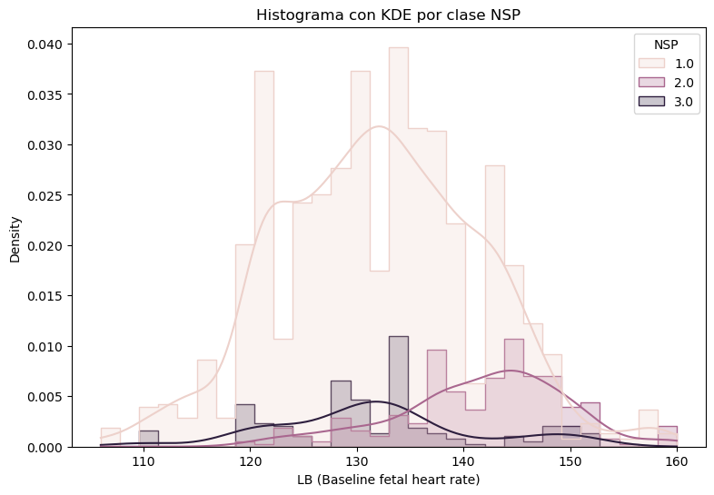

```python
# HHistogramas Añadir línea de densidad + KDE + customizable por grupo

plt.figure(figsize=(9,6))
sns.histplot(
    data=df_proc,
    x="LB",             # frecuencia cardiaca fetal basal
    hue="NSP",          # clases Normal / Sospechoso / Patológico
    kde=True,
    stat="density",
    bins=30,
    element="step"
)
plt.title("Histograma con KDE por clase NSP")
plt.xlabel("LB (Baseline fetal heart rate)")
plt.show()
```

Use el Df con outliers pues si los quito no puedo comparar las distribuciones pues desapareecen los valores para otras categorias diferente a "normal" comparamos las distribuciones para cada cetegoria, use NSP, la cual considera normal, sospechos y patologico, la distribucion de sospechoso esta mas cargada a la derecha y tiene una cola izquierda mas cargada

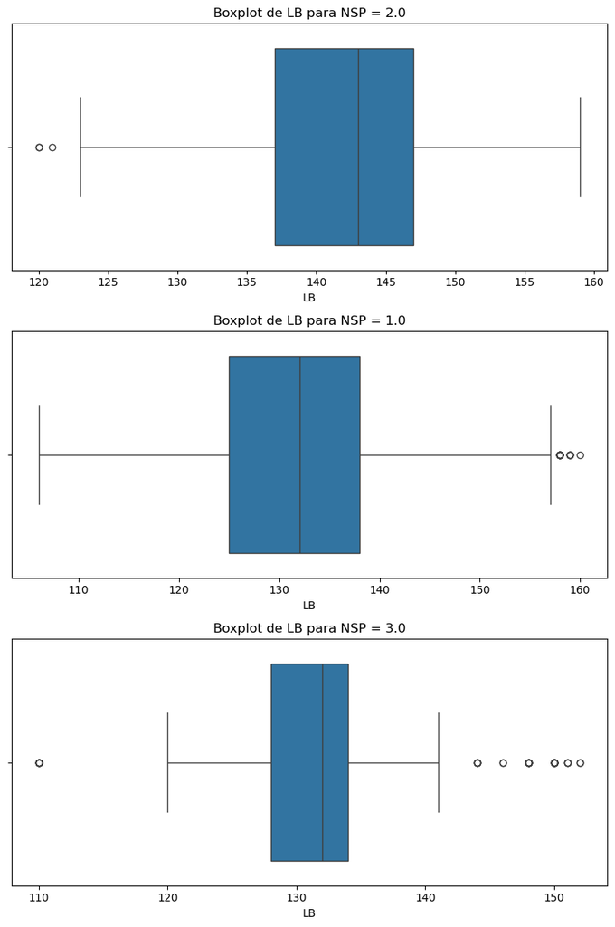

```python
# Boxplots Incluir subgráficos por clase objetivo
clases = df_imp["NSP"].unique()

fig, ejes = plt.subplots(len(clases), 1, figsize=(8, 12))

for i, clase in enumerate(clases):
    df_clase = df[df["NSP"] == clase]
    sns.boxplot(
        data=df_clase,
        x="LB",
        ax=ejes[i]
    )
    ejes[i].set_title(f"Boxplot de LB para NSP = {clase}")

plt.tight_layout()
plt.show()
```

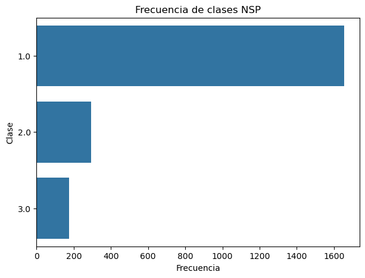

```python
#Barras Horizontales Ordenadas por frecuencia descendente
conteos = df["NSP"].value_counts()

plt.figure(figsize=(7,5))
sns.barplot(
    x=conteos.values,
    y=conteos.index,
    orient='h'
)
plt.title("Frecuencia de clases NSP")
plt.xlabel("Frecuencia")
plt.ylabel("Clase")
plt.show()
```

Camparamos los conteos para categoria y la normal tiene la mayoria, mientras que la patologica es la que menos observaciones tiene

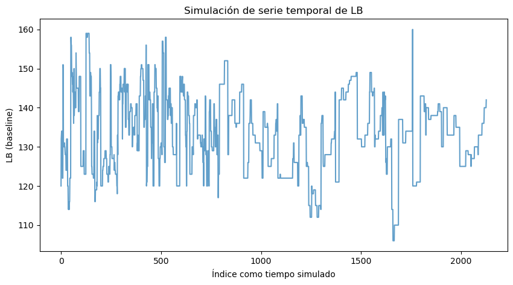

```python
#Líneas Simular serie temporal (ordenar por índice o simular variable de tiempo)
df_ordenado = df.sort_index()   # simulamos tiempo

plt.figure(figsize=(10,5))
plt.plot(df_ordenado.index, df_ordenado["LB"], alpha=0.7)
plt.title("Simulación de serie temporal de LB")
plt.xlabel("Índice como tiempo simulado")
plt.ylabel("LB (baseline)")
plt.show()
```

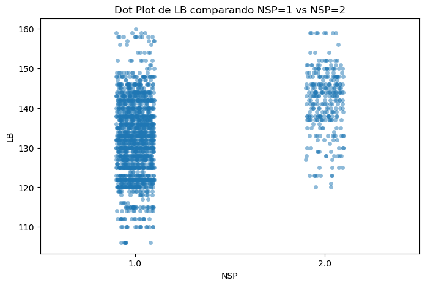

```python
#Dot Plots Comparación entre 2 grupos (overlay)
df_dos = df[df["NSP"].isin([1,2])]

plt.figure(figsize=(8,5))
sns.stripplot(
    data=df_dos,
    x="NSP",
    y="LB",
    jitter=True,
    alpha=0.5
)
plt.title("Dot Plot de LB comparando NSP=1 vs NSP=2")
plt.show()
```

Otra forma de ver la distribución de los datos y comprar , se nota la carga de la segunda categoria hacia valores medios sin observaciones el los valores bajos de LB

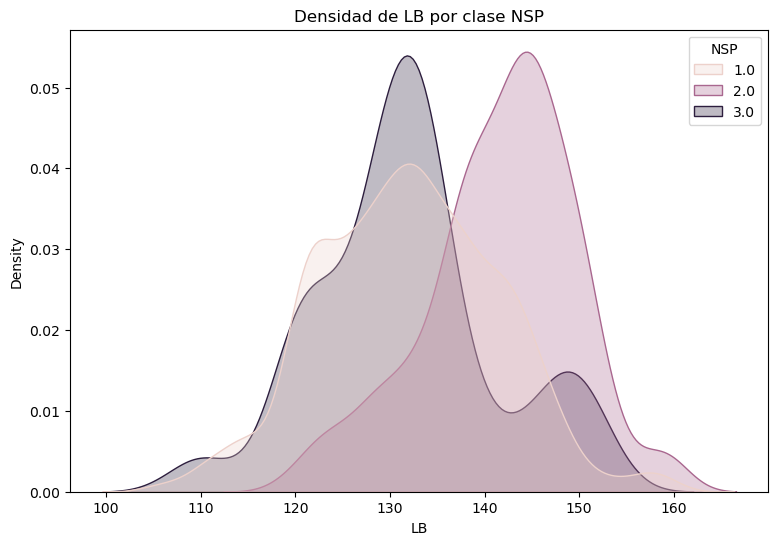

```python
#Densidad Múltiples clases con diferentes colores
plt.figure(figsize=(9,6))
sns.kdeplot(
    data=df,
    x="LB",
    hue="NSP",
    common_norm=False,
    fill=True,
    alpha=0.3
)
plt.title("Densidad de LB por clase NSP")
plt.show()
```

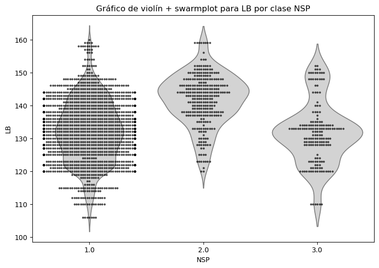

```python
#Violín Overlay con swarmplot
plt.figure(figsize=(9,6))

sns.violinplot(
    data=df,
    x="NSP",
    y="LB",
    inner=None,
    color="lightgray"
)

sns.swarmplot(
    data=df,
    x="NSP",
    y="LB",
    color="black",
    size=3,
    alpha=0.7
)

plt.title("Gráfico de violín + swarmplot para LB por clase NSP")
plt.show()
```

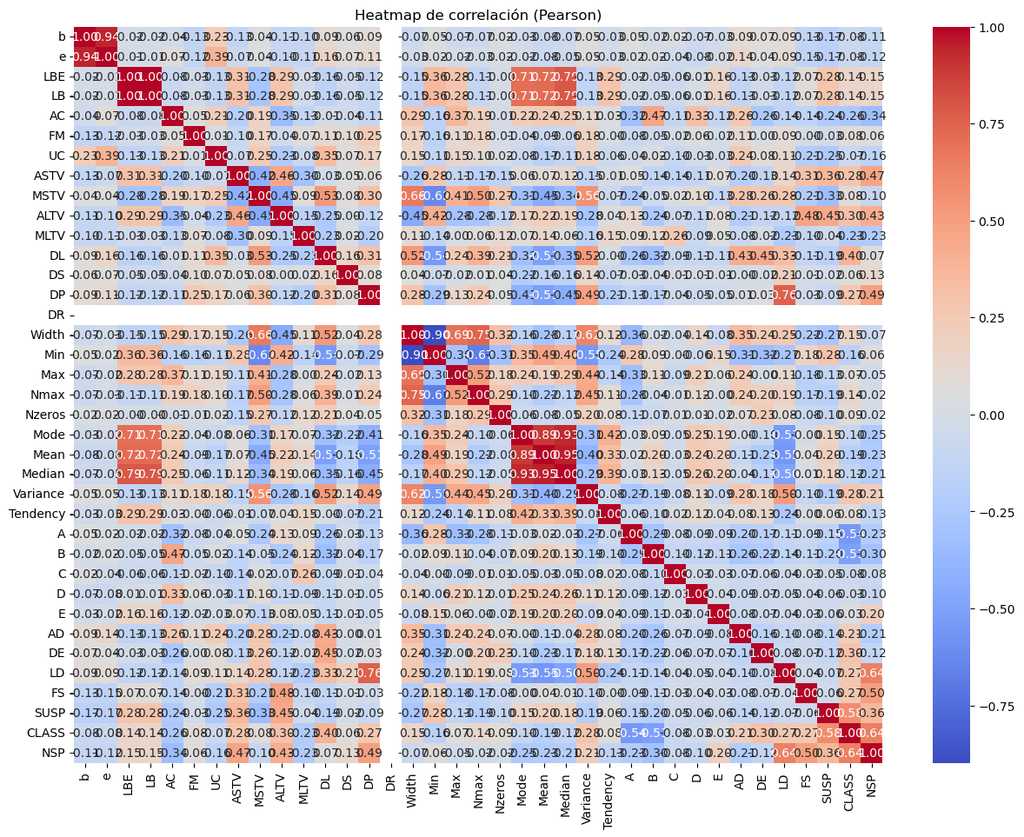

```python
#Heatmap Correlación + anotaciones y selección de método ('pearson', 'spearman')
corr_pearson = df[columnas_numericas].corr(method="pearson")

plt.figure(figsize=(15,11))
sns.heatmap(
    corr_pearson,
    annot=True,
    fmt=".2f",
    cmap="coolwarm"
)
plt.title("Heatmap de correlación (Pearson)")
plt.show()
```

Hay varias variables con una alta correlacion Son redundantes; podemos considerar reducción de dimensionalidad (PCA) o eliminar algunas.